# How to Work with Data from a Subsystem

Data from the Net Zero house includes 400+ variables that include readings from instrumentation around the house in one minute increments. Each of these variables, also called channels in NIST documentation, provides the readings from one instrument, and the instruments are grouped into subsystems:

DHW - Domestic Hot Water SHW - Solar Hot Water Load - Electrical and Thermal Loads by equipment and people HVAC - Heating and Cooling System IndEnv - Indoor Environment PV - Photovoltaic OutEnv - Outdoor Environment Vent - Ventilation Elec - Electrical

This tutorial walks through loading data from a particular subsystem.

## Get the data you need

If you want to analyze net-zero data for specific subsystems, rather than data for the whole house, you can download the data from the Net Zero website and import it into R, or you can use the download link directly.

For example, if you wanted to analyze the channels (like the heat pump air flow rate or the total power used by the heat pump) in the HVAC subsystem, you could pull data for that subsystem:

```r
# load libraries
library(ggplot2) # plotting library

# get data
#hvac <- read.csv("https://s3.amazonaws.com/nist-netzero/2015-data-files/HVAC.csv", header=TRUE, na.strings=c("NA", "NULL", "", " "))
# delete the line below and uncomment the line above
hvac <- read.csv("/Users/prioberoi/Documents/nist/netZero/data/processed/HVAC.csv", header=TRUE, na.strings=c("NA", "NULL", "", " "))
```

Here are the variables included in the HVAC subsystem data. The nomenclature includes the name of the Sub System and the name of the channel as SubSystem_Channel.

```r
names(hvac)
```

```
##  [1] "Timestamp"
##  [2] "TimeStamp_Count"
##  [3] "TimeStamp_SchedulerTime"
##  [4] "TimeStamp_SystemTime"
##  [5] "DayOfWeek"
##  [6] "HVAC_HVACDeltaPPressureDiffacrossIndoorUnit"
##  [7] "HVAC_HVACDewpointReturnAir"
##  [8] "HVAC_HVACDewpointSupplyAir"
##  [9] "HVAC_HVACTempReturnAir"
## [10] "HVAC_HVACTempSupplyAir"
## [11] "HVAC_HeatPumpIndoorEnergyTotal"
## [12] "HVAC_HeatPumpIndoorPowerTotal"
## [13] "HVAC_HeatPumpOutdoorEnergyTotal"
## [14] "HVAC_HeatPumpOutdoorPowerTotal"
## [15] "HVAC_HeatPumpEnergyIndoorunit"
## [16] "HVAC_HeatPumpEnergyOutdoorUnit"
## [17] "HVAC_X1421IDUnitPowerDemandW"
## [18] "HVAC_X1422ODUnitPowerDemandW"
## [19] "HVAC_X1423UltraAire70HPowerW"
## [20] "HVAC_UltraAire70HInletAirAvgTempF"
## [21] "HVAC_UltraAire70HExitAirAvgTempF"
## [22] "HVAC_UltraAire70HAirflowCFM"
```

## Working with the data

Once you have your data, you can visualize the Supply and Return air temperatures by season.

First, convert Timestamp into a date/time format using strptime():

```r
# converts Timestamp variable into date/time format (POSIXlt)
hvac$Timestamp <- strptime(hvac$Timestamp, "%Y-%m-%d %H:%M:%S")

# quick check of the values in the Timestamp variable
hvac$Timestamp[1:10]
```

```
##  [1] "2015-02-01 00:00:00 CST" "2015-02-01 00:01:00 CST"
##  [3] "2015-02-01 00:02:00 CST" "2015-02-01 00:03:00 CST"
##  [5] "2015-02-01 00:04:00 CST" "2015-02-01 00:05:00 CST"
##  [7] "2015-02-01 00:06:00 CST" "2015-02-01 00:07:00 CST"
##  [9] "2015-02-01 00:08:00 CST" "2015-02-01 00:09:00 CST"
```

Now we can use the Timestamp variable to create a new categorical ‘season’ variable:

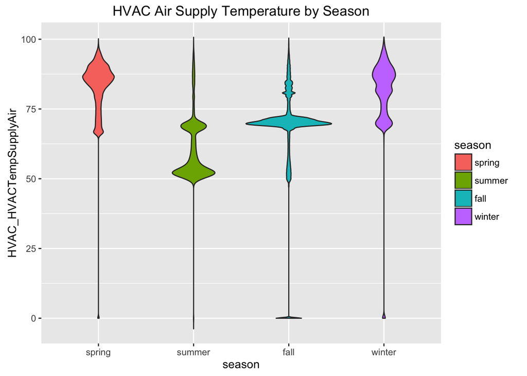

```r
# create a variable for seasons
hvac$season <- "summer"
hvac$season[hvac$Timestamp < '2015-03-20 12:30:00'] <- "spring"
hvac$season[hvac$Timestamp > '2015-09-22 10:21:00' & hvac$Timestamp < '2015-12-21 05:44:00'] <- "fall"
hvac$season[hvac$Timestamp > '2015-12-21 05:44:00'] <- "winter"
hvac$season <- ordered(hvac$season, levels = c("spring", "summer", "fall", "winter"))

# now we can do things like group readings by season
ggplot(hvac, aes(x = season, y = HVAC_HVACTempSupplyAir, fill = season)) +
  geom_violin(scale = "area") +
  ggtitle("HVAC Air Supply Temperature by Season")
```

Additionally, we can compare readings between channels in the subsystem; this compares the air temperature in the HVAC supply air with the retun air:

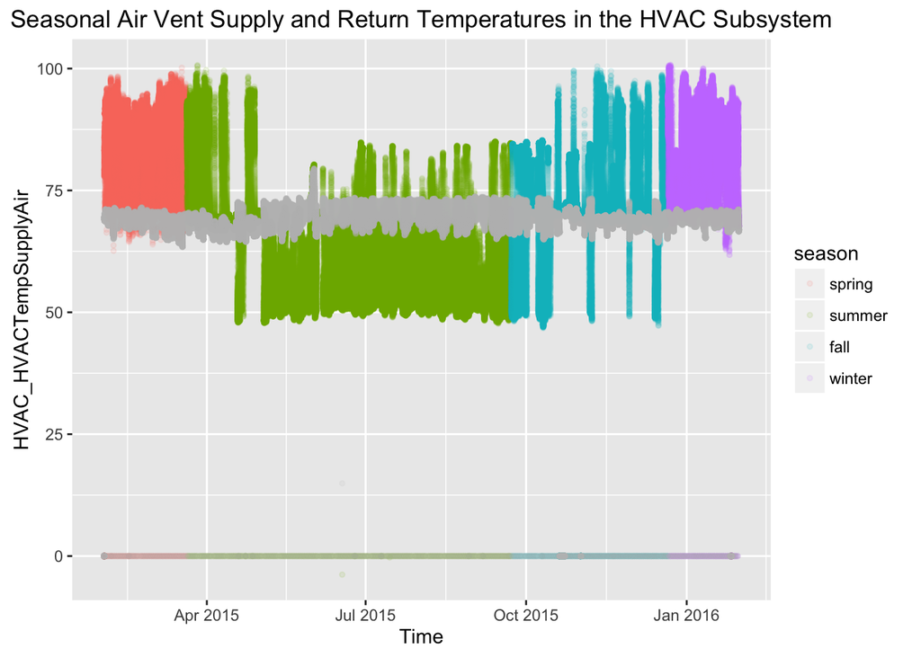

```r
# Visualize supply and return air temperature
ggplot(hvac, aes(x = Timestamp)) +
  geom_point(aes(y = HVAC_HVACTempSupplyAir, colour = season), alpha = 0.10, size = 1) +
  geom_point(aes(y = HVAC_HVACTempReturnAir), colour = "grey", alpha = 0.10, size = 1) +
  xlab("Time") +
  ggtitle("Seasonal Air Vent Supply and Return Temperatures in the HVAC Subsystem")
```